# Numerical ecology

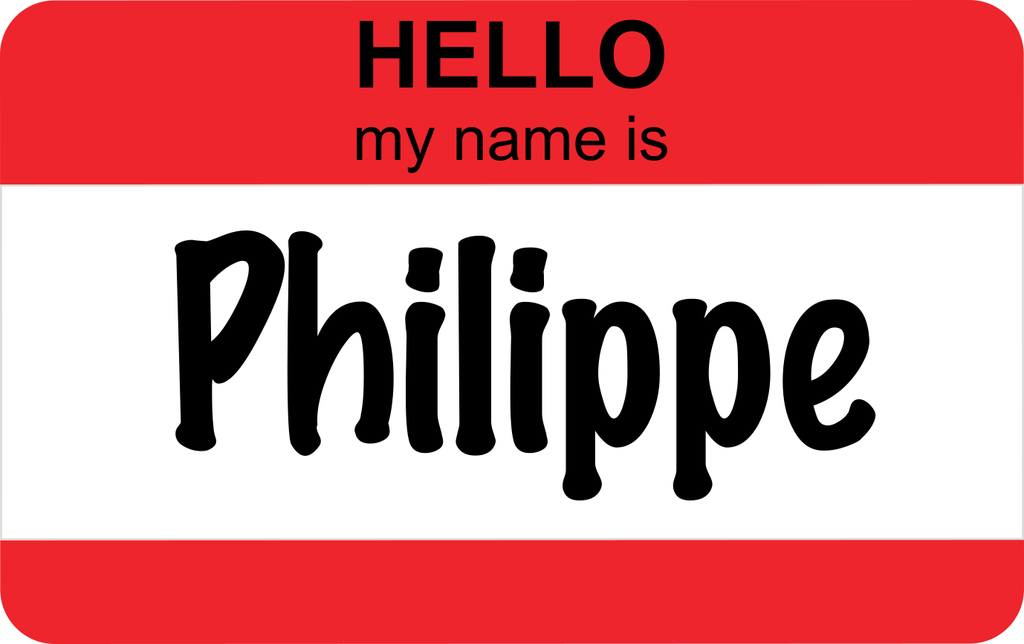

Research assistant at Takuvik (Laval University, Québec, Canada)

- Remote sensing
- Modeling & statistics
- Data sciences

## Data science

> Data Science is an interdisciplinary field about processes and systems to **extract knowledge or insights from large volumes of data** in various forms, either structured or unstructured (Wikipedia).

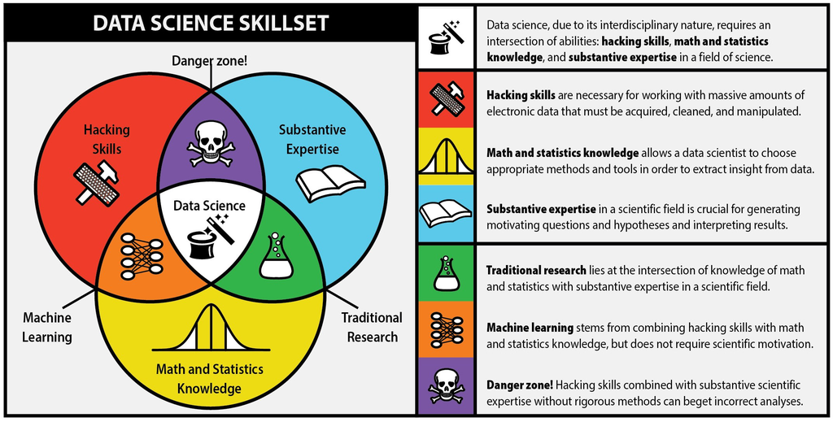

Source: http://berkeleysciencereview.com/article/first-rule-data-science

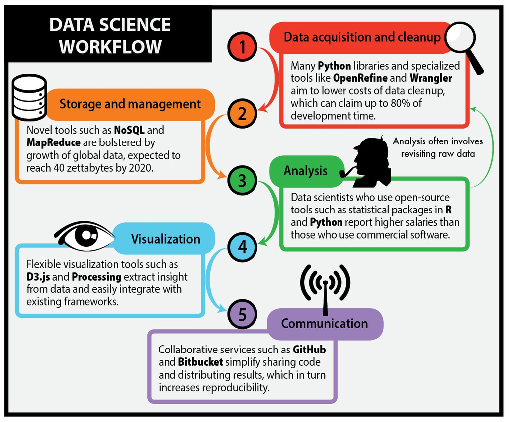

Source: http://berkeleysciencereview.com/article/first-rule-data-science

## Data science in ecology

- Data relevant to environmental issues is produced very rapidly at high spacial and temporal scales.
  - Remote sensing, animal tagging/tracking
  - Automated *in-situ* sensors (salinity, Chl*a*, …)
  - *No, we are not doing big data science*
- As scientists, **you need** to learn and practice essential tools for capturing, manipulating and sharing data.
- I wish I knew more about code workflow and data organization when I started my PhD!

## What is this class about

- Provide tools (**R**) and knowledge (**statistics**) for ecologists.
- Focus on **understanding what you are doing** not necessary on the mathematical details.
  - $x(n)y(n) \Leftrightarrow \frac{1}{{2\pi }}\int\limits_{ - \pi }^\pi {X(e^{j\theta } )Y(e^{j(\omega - \theta )} )d\theta }$
- Best practices to data manipulation and data analysis.

## Why programing?

You might wonder **why it is important to learn programming in science**. There are *at least* two good reasons:

1. Reproducibility (ability to recreate what you did).
2. Automation (run existing analysis on new data).

## Why is it important?

> It is often said that 80% of data analysis is spent on the cleaning and preparing data. And it’s not just a first step, but it must be repeated many over the course of analysis as new problems come to light or new data is collected (Hadley Whickham).

## Why using R

During this course we will focus on R.

- It is a free software!
- It is cross-platforms (Windows, Mac and Linux).
- Has exceptional graphics capabilities (ideal for preparing scientific manuscripts).
- Easy to develop your own functions (**automation**).
- Allows to keep a trace on how analyzes have been done (**reproducible**).
- Packages and active development (10 000+ packages available on CRAN).

## Outline

This course will be divided into two main parts:

1. An introduction to R (data manipulation, graphics, etc.)
2. Statistical analysis using R

## Class schedule

- Introduction to R
- Data manipulation (working with real data)
- Introduction to `ggplot2`
- Statistics
  - t.test, ANOVA
  - Linear regressions
  - Data transformation
  - Variance partitioning
  - Canonical analysis
    - Principal component analysis (PCA)
    - Redundancy analysis (RDA)
  - Generalized linear models (GLM)
  - Introduction to spatial analysis

## What I am expecting

**Your participation.**

The best way to learn programming and statistics is by practicing. After each concept, we will do exercises together.

## Class notes

http://www.pmassicotte.com/stats-denmark-2019/

## Installing R and RStudio

*Download R* https://cran.r-project.org/

**I strongly recommend to install RStudio as your integrated developing environment (IDE).**

*Download RStudio* https://www.rstudio.com/products/RStudio/